# R Notebook

**Зад. 1** Напишете функция, която симулира 100 хвърнляния на зар и пресмята броя на падналите се шестици.

```r
roll <- function() {
  return(rbinom(1, 100, 1/6))
}
```

Изпълнете функцията *n* пъти и въз основа на получените данни сметнете емпиричната вероятност да се падне шестица.

```r
p <- function(n = 100) {
  observations = c()
  for(i in 1:n) {
    observations[i] = roll()
  }

  return (sum(observations) / (n * 100))
}
p()
```

```
[1] 0.1645
```

Постройте графика, която да илюстрира сходимостта на емпиричната вероятност към теоретичната.

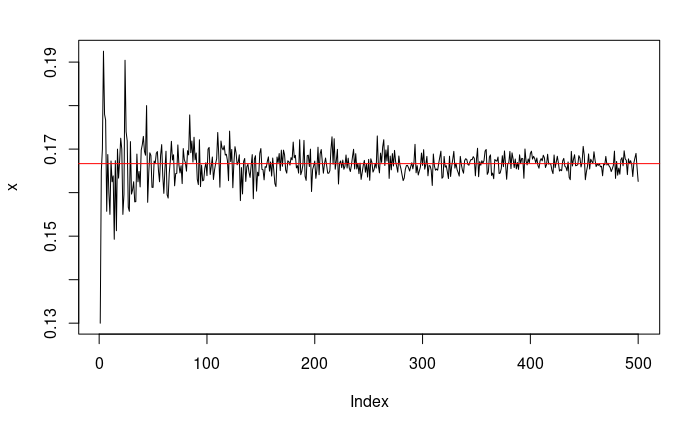

```r
probabilities = function(n = 100) {
  r = c()

  for(i in 1:n) {
    r[i] = p(i)
  }

  return(r)
}
x = probabilities(500)
plot(x, type = 'l')
abline(h = 1/6, col = 'red' )
```

**Зад. 2** Напишете функция, която по дадено число *p∈(0,1)* пресмята колко човека трябва да изберете по случаен начин, така че вероятността рождените дни на поне двама от тях да съвпадата да е по-голяма от p.

```r
birthdays <- function( p = 0.5 ){
  prob = 1;
  for(i in 1:365) {
    prob = prob * (366-i) / 365
    if(prob < 1 - p) break
  }
  return(i)
}
birthdays()
```

```
[1] 23
```

**Зад. 3** Момче играе с майка си и баща си на тенис. Те ще изиграят точно 3 сета, като родителите се редуват, т.е има две възможности за момчето да играе:  
А) Първо с майка си, после с баща си и пак с майка си.  
Б) Първо с баща си, после с майка си и пак с баща си.

**Зад. 4** Нека ‘Е’ и ‘Т’ са съответно падане на ези и тура при хвърляне на монета. Напишете функция, която пресмята емпирично колко хвърляния са необходими до падането на последователност ‘ЕЕТЕТ’.

```r
letters = c('E', 'T')
count_flips <- function(target) {
  count = 1

  while(TRUE) {
    current = sample(letters, length(target), TRUE)

    if(identical(current, target)) {
      break
    }

    count = count + 1
  }


  return(count)
}
count_flips(c('E', 'E', 'T', 'E', 'T'))
```

```
[1] 16
```